# Exercise 03

Author

Xiaocheng Yang(YXC33)

Published

October 2, 2023

## Exploratory Data Analysis

Do an exploratory data analysis of a matrix of expression values. The data consists of expression values for samples that were treated with DMSO and TSA. The samples were measured using three technologies: bulk, IFC96, IFC800. See the two RDS files `counts.RDS` and `phenodata.RDS`.

The experiment has two experimental factors “Treatment” and “Technology”. Treatment has two levels, Technology has three levels. Samples that have the same combination of Treatment & Technology are replicates.

## Data Import

```r
x = readRDS("counts.RDS")
anno = readRDS("phenodata.RDS")
head(anno)
```

```
                      Treatment Technology
bulk.DMSO-Pre-96IFC        DMSO       bulk
bulk.TSA-Pre-96IFC          TSA       bulk
bulk.DMSO-Pre-800IFC       DMSO       bulk
bulk.TSA-Pre-800IFC         TSA       bulk
bulk.DMSO-Post-800IFC      DMSO       bulk
bulk.TSA-Post-800IFC        TSA       bulk
```

## Compute and visualize basic statistics on the experimental design

How many replicates are there for each combination of factor levels? How many genes have an expression value above 0 in each sample? Are there systematic differences between the samples in the different conditions (treatment & technology). Visualize the following statistics per sample:

### How many replicates are there for each combination of factor levels?

```r
table(anno)
```

```
         Technology
Treatment bulk IFC800 IFC96
     DMSO    3     20    20
     TSA     3     20    20
```

So, for (DMSO,bulk) combination, we have 3 replicas; for(DMSO,IFC800), we have 20 replicas; for (DMSO,IFC96), we have 20 replicas; for (TSA, bulk), we have 3 replicas; for(TSA,IFC800), we have 20 replicas; for(TSA, IFC96) we have 20 replicas.

### How many genes have an expression value above 0 in each sample?

```r
bigger_0 <- apply(x, MARGIN = 2, FUN = function(col) sum(col>0))
print(bigger_0)
```

```
                     bulk.DMSO-Pre-96IFC
                                   15163
                      bulk.TSA-Pre-96IFC
                                   15261
                    bulk.DMSO-Pre-800IFC
                                   15404
                     bulk.TSA-Pre-800IFC
                                   16182
                   bulk.DMSO-Post-800IFC
                                   15202
                    bulk.TSA-Post-800IFC
                                   16167
    ifc96.LIB018588_GEN00046618_S78_L001
                                    7862
    ifc96.LIB018588_GEN00046619_S79_L001
                                    8537
    ifc96.LIB018588_GEN00046620_S80_L001
                                     404
    ifc96.LIB018588_GEN00046621_S81_L001
                                    7479
    ifc96.LIB018588_GEN00046622_S82_L001
                                    7003
    ifc96.LIB018588_GEN00046623_S83_L001
                                    8886
    ifc96.LIB018588_GEN00046624_S84_L001
                                    9314
    ifc96.LIB018588_GEN00046625_S85_L001
                                    8616
    ifc96.LIB018588_GEN00046626_S86_L001
                                    5450
    ifc96.LIB018588_GEN00046627_S87_L001
                                    7121
    ifc96.LIB018588_GEN00046628_S88_L001
                                     557
    ifc96.LIB018588_GEN00046629_S89_L001
                                    6697
    ifc96.LIB018588_GEN00046630_S90_L001
                                    9123
    ifc96.LIB018588_GEN00046631_S91_L001
                                    8138
```

[output cut: 117 more lines]

```
                                    8320
ifc800.COL11_ROW14_LIB018723-GEN00047362
                                    5239
ifc800.COL11_ROW15_LIB018723-GEN00047362
                                    5442
ifc800.COL11_ROW16_LIB018723-GEN00047362
                                    1125
ifc800.COL11_ROW17_LIB018723-GEN00047362
                                    4682
ifc800.COL11_ROW18_LIB018723-GEN00047362
                                    5005
ifc800.COL11_ROW19_LIB018723-GEN00047362
                                    9074
ifc800.COL11_ROW20_LIB018723-GEN00047362
                                    6029
```

Here is the table that shows how many genes are expressed in every sample.

### number of detected genes

```r
bigger_0 <- apply(x, MARGIN = 2, FUN = function(col) sum(col>0))
print(bigger_0)
```

```
                     bulk.DMSO-Pre-96IFC
                                   15163
                      bulk.TSA-Pre-96IFC
                                   15261
                    bulk.DMSO-Pre-800IFC
                                   15404
                     bulk.TSA-Pre-800IFC
                                   16182
                   bulk.DMSO-Post-800IFC
                                   15202
                    bulk.TSA-Post-800IFC
                                   16167
    ifc96.LIB018588_GEN00046618_S78_L001
                                    7862
    ifc96.LIB018588_GEN00046619_S79_L001
                                    8537
    ifc96.LIB018588_GEN00046620_S80_L001
                                     404
    ifc96.LIB018588_GEN00046621_S81_L001
                                    7479
    ifc96.LIB018588_GEN00046622_S82_L001
                                    7003
    ifc96.LIB018588_GEN00046623_S83_L001
                                    8886
    ifc96.LIB018588_GEN00046624_S84_L001
                                    9314
    ifc96.LIB018588_GEN00046625_S85_L001
                                    8616
    ifc96.LIB018588_GEN00046626_S86_L001
                                    5450
    ifc96.LIB018588_GEN00046627_S87_L001
                                    7121
    ifc96.LIB018588_GEN00046628_S88_L001
                                     557
    ifc96.LIB018588_GEN00046629_S89_L001
                                    6697
    ifc96.LIB018588_GEN00046630_S90_L001
                                    9123
    ifc96.LIB018588_GEN00046631_S91_L001
                                    8138
```

[output cut: 117 more lines]

```
                                    8320
ifc800.COL11_ROW14_LIB018723-GEN00047362
                                    5239
ifc800.COL11_ROW15_LIB018723-GEN00047362
                                    5442
ifc800.COL11_ROW16_LIB018723-GEN00047362
                                    1125
ifc800.COL11_ROW17_LIB018723-GEN00047362
                                    4682
ifc800.COL11_ROW18_LIB018723-GEN00047362
                                    5005
ifc800.COL11_ROW19_LIB018723-GEN00047362
                                    9074
ifc800.COL11_ROW20_LIB018723-GEN00047362
                                    6029
```

This table is the number of detected genes per sample.

### Are there systematic differences between the samples in the different conditions

For now, it’s really hard to say, because we have not normalized data.

### total sum of counts per sample (serves as a proxy for the number of sequenced reads per sample)

```r
sum_counts_sample <- apply(x, MARGIN = 2, FUN = function(col) sum(col))
print(sum_counts_sample)
```

```
                     bulk.DMSO-Pre-96IFC
                                16469072
                      bulk.TSA-Pre-96IFC
                                10899777
                    bulk.DMSO-Pre-800IFC
                                22928016
                     bulk.TSA-Pre-800IFC
                                21170430
                   bulk.DMSO-Post-800IFC
                                16572277
                    bulk.TSA-Post-800IFC
                                21218842
    ifc96.LIB018588_GEN00046618_S78_L001
                                  540928
    ifc96.LIB018588_GEN00046619_S79_L001
                                  476007
    ifc96.LIB018588_GEN00046620_S80_L001
                                    2086
    ifc96.LIB018588_GEN00046621_S81_L001
                                  380036
    ifc96.LIB018588_GEN00046622_S82_L001
                                   17687
    ifc96.LIB018588_GEN00046623_S83_L001
                                  643503
    ifc96.LIB018588_GEN00046624_S84_L001
                                  386731
    ifc96.LIB018588_GEN00046625_S85_L001
                                  672686
    ifc96.LIB018588_GEN00046626_S86_L001
                                  427782
    ifc96.LIB018588_GEN00046627_S87_L001
                                  843348
    ifc96.LIB018588_GEN00046628_S88_L001
                                   14150
    ifc96.LIB018588_GEN00046629_S89_L001
                                   77791
    ifc96.LIB018588_GEN00046630_S90_L001
                                  709392
    ifc96.LIB018588_GEN00046631_S91_L001
                                 1060374
```

[output cut: 117 more lines]

```
                                  400023
ifc800.COL11_ROW14_LIB018723-GEN00047362
                                  114036
ifc800.COL11_ROW15_LIB018723-GEN00047362
                                  112770
ifc800.COL11_ROW16_LIB018723-GEN00047362
                                    2743
ifc800.COL11_ROW17_LIB018723-GEN00047362
                                   77436
ifc800.COL11_ROW18_LIB018723-GEN00047362
                                   92052
ifc800.COL11_ROW19_LIB018723-GEN00047362
                                  676421
ifc800.COL11_ROW20_LIB018723-GEN00047362
                                  204180
```

This table shows the total sum of counts per sample.

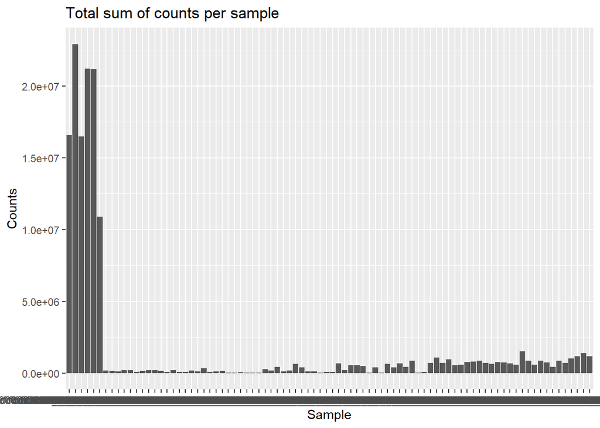

```r
library("ggplot2")
dataframe_sum_of_counts <- data.frame(value = sum_counts_sample, index = names(sum_counts_sample))

ggplot(dataframe_sum_of_counts, aes(x=factor(index), y = value))+
    geom_bar(stat="identity")+
    labs(title = "Total sum of counts per sample", x="Sample", y="Counts")
```

We find that the total counts of different sample vary a lot. Find that sample names overlaoed on x-axis.

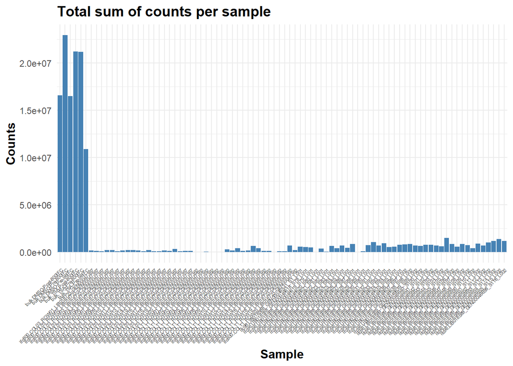

```r
ggplot(dataframe_sum_of_counts, aes(x=factor(index), y=value)) +
    geom_bar(stat="identity", fill="steelblue") +
    labs(title="Total sum of counts per sample", x="Sample", y="Counts") +
    theme_minimal() +
    theme(axis.text.x = element_text(size=4.5, angle = 45, hjust = 1, vjust = 1),
          plot.title = element_text(face="bold", size=14),
          axis.title.x = element_text(size=12, face="bold"),
          axis.title.y = element_text(size=12, face="bold"))
```

From this table, we can find that different sample counts vary a lot.

### Color the samples by the experimental condition.

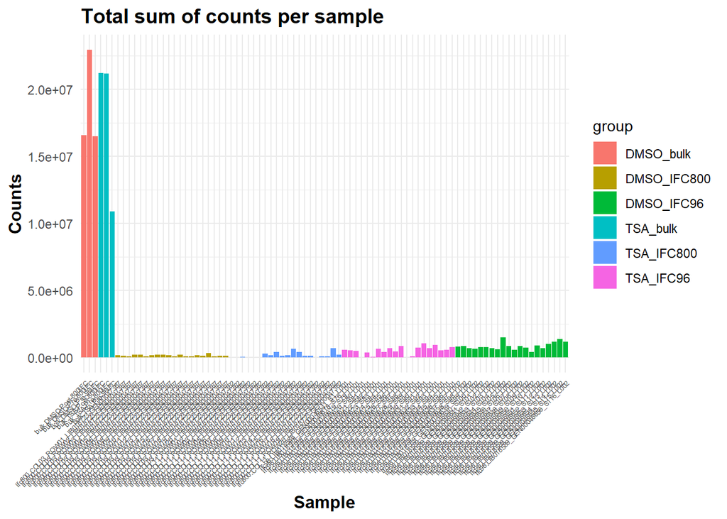

```r
library(dplyr)
anno$sample_name <- rownames(anno) # add one column(sample names) in anno

anno <- anno%>% mutate(group = paste(Treatment,Technology, sep = "_")) # add one column(different combinations) in anno
merged_data <- left_join(dataframe_sum_of_counts,anno,by=c("index" = "sample_name"))
ggplot(merged_data, aes(x=factor(index), y=value)) +
    geom_bar(stat="identity",aes(fill= group)) +
    labs(title="Total sum of counts per sample", x="Sample", y="Counts") +
    theme_minimal() +
    theme(axis.text.x = element_text(size=4.5, angle = 45, hjust = 1, vjust = 1),
          plot.title = element_text(face="bold", size=14),
          axis.title.x = element_text(size=12, face="bold"),
          axis.title.y = element_text(size=12, face="bold"))
```

After colored, we can find that there are two groups of sample have really high number of counts.

## Normalize the data

Scale the columns so that the total sum of all columns are identical

```r
total_counts <- colSums(x)
normalized_data <- t(t(x)/total_counts*1e6)
# use t(), because when a matrix divided by a vector. It divided by column.
```

Because we are not given the gene length of every gene, I would use CPM(Counts Per Million, t(data) / total_counts * 1e6) but not TPM or FPKM.

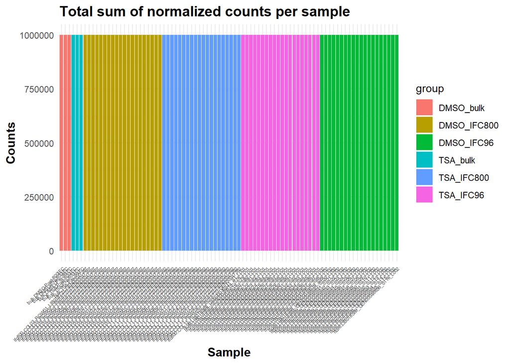

```r
library(dplyr)
normalized_sum_data <- colSums(normalized_data)
dataframe_sum_of_normalized_counts <- data.frame(value = normalized_sum_data, index = names(normalized_sum_data))

merged_normalized_data <- left_join(dataframe_sum_of_normalized_counts,anno,by=c("index" = "sample_name"))
ggplot(merged_normalized_data, aes(x=factor(index), y=value)) +
    geom_bar(stat="identity",aes(fill= group)) +
    labs(title="Total sum of normalized counts per sample", x="Sample", y="Counts") +
    theme_minimal() +
    theme(axis.text.x = element_text(size=4.5, angle = 45, hjust = 1, vjust = 1),
          plot.title = element_text(face="bold", size=14),
          axis.title.x = element_text(size=12, face="bold"),
          axis.title.y = element_text(size=12, face="bold"))
```

From this plot, we know that after CPM normalized, the total sum of all columns are identical.

## Transform the data to log-scale

```r
#working with data where you have a lot of zeros or low counts. The benefit of using #log1p over just log is that it gracefully handles zero values without causing -Inf #values.
transformed_data <- log1p(normalized_data)
```

Use the function `log1p` to transform the data to log-scale

## Visualize the distribution of the expression values

Use violin plots and boxplots to visualize the distribution of the expression values. Aggregate the replicates in the same experimental group into one average sample, and plot the averaged sample. Color by experimental factors.

### Violin plots

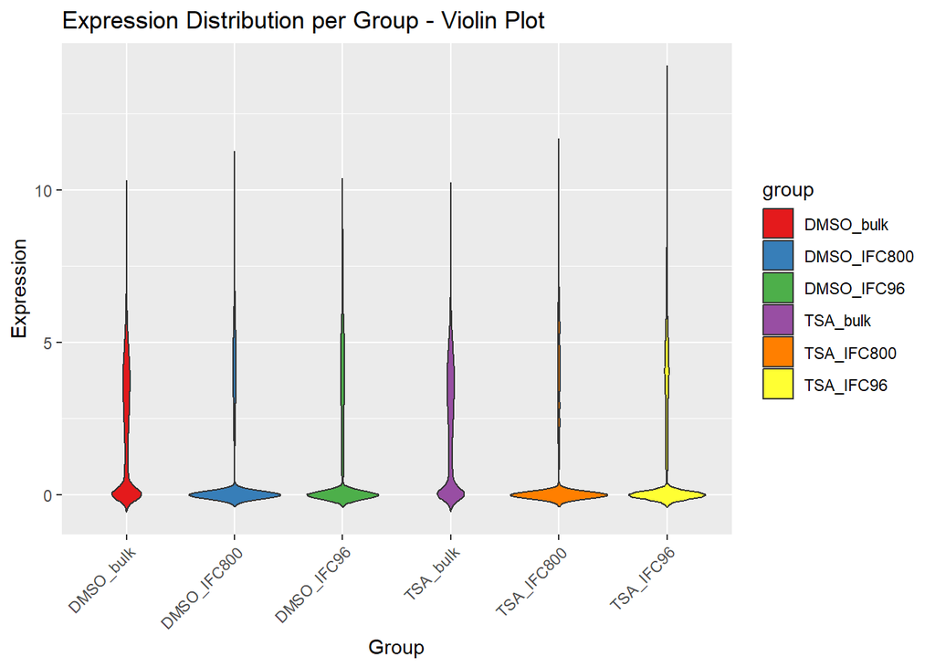

```r
library(dplyr)
library(tidyr)
library(ggplot2)
df_transformed_data <- as.data.frame(transformed_data)
df_transformed_data$gene <- rownames(transformed_data)
#chang to long version
df_long <- df_transformed_data %>%
  gather(sample, expression, -gene)
merged_transformed_data <- left_join(df_long, anno, by = c("sample" = "sample_name"))

ggplot(merged_transformed_data, aes(x=group, y=expression, fill=group)) +
  geom_violin(trim=FALSE) +
  labs(title="Expression Distribution per Group - Violin Plot", x="Group", y="Expression") +
  theme(axis.text.x = element_text(angle=45, hjust=1)) +
  scale_fill_brewer(palette="Set1")
```

From this violin plot, we can find that most of the gene expression is 0 no matter which group. But DMSO_bulk and TSA_bulk have fewer genes expressed around 0, compared with others.

### boxplots

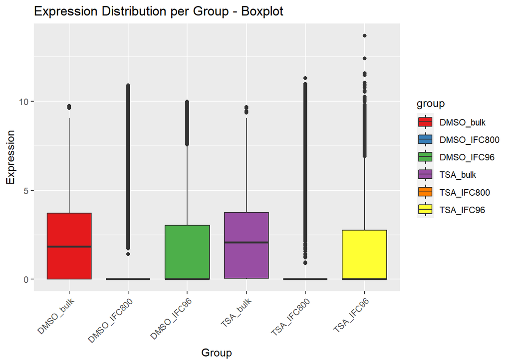

```r
ggplot(merged_transformed_data, aes(x=group, y=expression, fill=group)) +
  geom_boxplot() +
  labs(title="Expression Distribution per Group - Boxplot", x="Group", y="Expression") +
  theme(axis.text.x = element_text(angle=45, hjust=1)) +
  scale_fill_brewer(palette="Set1")
```

Compared with violin plots, it is hard to see the structure inside. But we still can find the median values of DMSO_bulk and TSA_bulk are higher than others.

### Aggregate the replicates in the same experimental group into one average sample, and plot the averaged sample.

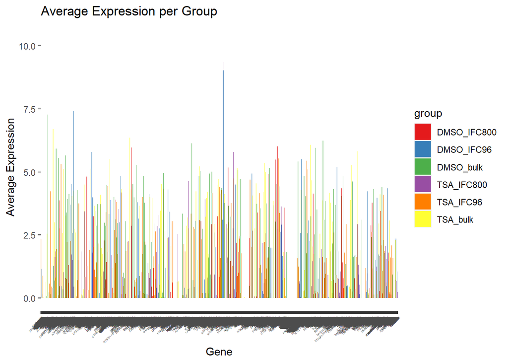

```r
averaged_data <- merged_transformed_data %>%
  group_by(gene, group) %>%
  summarize(average_expression = mean(expression, na.rm = TRUE))
averaged_data <- averaged_data %>%
  arrange(group) %>%
  mutate(group = factor(group, levels = unique(group)))

ggplot(averaged_data, aes(x=gene, y=average_expression, fill=group)) +
  geom_bar(stat="identity", position="dodge") +
  labs(title="Average Expression per Group", x="Gene", y="Average Expression") +
  theme(axis.text.x = element_text(size=2.5,angle=45, hjust=1)) +
  scale_fill_brewer(palette="Set1")
```

It is hard to see the difference of gene expression between different experimental group. It’s so hard to separate every gene name at X-axis.

## Most variable genes

Identify the 500 most variable genes (with largest variance across samples) and continue working with those

```r
library(dplyr)

# Compute variance for each gene across samples
variances <- apply(df_transformed_data[,-which(names(df_transformed_data) == "gene")], 1, var)

# Rank genes by variance and select the top 500
top_genes <- data.frame(
    gene = df_transformed_data$gene,
    variance = variances
) %>%
    arrange(desc(variance))%>%
    head(500)

top_500_genes_data <- df_transformed_data[top_genes$gene, ]
```

## Sample correlations

Compute and visualize the sample-to-sample correlations

[figure not shown]

```r
#the use of the t function to transpose the dataset so that we're calculating correlations of genes between samples.
correlation_matrix <- cor(t(top_500_genes_data[,-which(names(df_transformed_data) == "gene")]))
library(pheatmap)
# computing cluster
row_hclust <- hclust(as.dist(1 - correlation_matrix), method = "complete")
col_hclust <- hclust(as.dist(1 - correlation_matrix), method = "complete")

# heatmap
pheatmap(correlation_matrix,
         main = "Sample-to-Sample Correlations",
         Rowv = as.dendrogram(row_hclust),
         Colv = as.dendrogram(col_hclust),
         show_rownames = TRUE,
         fontsize_row = 1,
         show_colnames = TRUE,
         fontsize_col=1)
```

Of course, we can use other method to visualize the correlations. for example:

```r
# library(corrplot)
# corrplot(correlation_matrix, method="circle",cl.cex=0.1)
```

## Clustering

Compute and visualize a hierarchical clustering of the samples, use the method `hclust`

[figure not shown]

```r
dist_matrix <- as.dist(1 - cor(t(top_500_genes_data[,-which(names(df_transformed_data) == "gene")])))
hc <- hclust(dist_matrix, method="complete")
plot(hc, main="Hierarchical Clustering of Samples", xlab="Samples", ylab="Height",cex=0.2)
```

## Heatmap

Use the package `pheatmap` to generate a heatmap of the expression data.

[figure not shown]

```r
# heatmap
pheatmap(correlation_matrix,
         main = "Sample-to-Sample Correlations",
         Rowv = as.dendrogram(row_hclust),
         Colv = as.dendrogram(col_hclust),
         show_rownames = TRUE,
         fontsize_row = 1,
         show_colnames = TRUE,
         fontsize_col=1)
```